# Prediction Assignment Writeup

Radu-Ionel Toma

11/22/2020

## Synopsis

Using devices such as Jawbone Up, Nike FuelBand, and Fitbit it is now possible to collect a large amount of data about personal activity relatively inexpensively. These type of devices are part of the quantified self movement – a group of enthusiasts who take measurements about themselves regularly to improve their health, to find patterns in their behavior, or because they are tech geeks. One thing that people regularly do is quantify how much of a particular activity they do, but they rarely quantify how well they do it. In this project, your goal will be to use data from accelerometers on the belt, forearm, arm, and dumbell of 6 participants. They were asked to perform barbell lifts correctly and incorrectly in 5 different ways.

The goal of this project is to predict the manner in which they did the exercise. This is the `classe` variable in the training set.

## Data description

The outcome variable is `classe`, a factor variable with 5 levels. For this data set, participants were asked to perform one set of 10 repetitions of the Unilateral Dumbbell Biceps Curl in 5 different fashions:

- exactly according to the specification (Class A)
- throwing the elbows to the front (Class B)
- lifting the dumbbell only halfway (Class C)
- lowering the dumbbell only halfway (Class D)
- throwing the hips to the front (Class E)

## Methodology

The `pml-training.csv` data is used to devise training and testing sets. The `pml-test.csv` data is used to predict and answer the 20 questions based on the trained model.

## Data processing

In this section the data is downloaded and processed. Some basic transformations and cleanup will be performed, so that `NA` values are omitted. Irrelevant columns such as `user_name`, `raw_timestamp_part_1`, `raw_timestamp_part_2`, `cvtd_timestamp`, `new_window`, and `num_window` (columns 1 to 7) will be removed in the subset.

The data was loaded using the following commands. The na.strings setting helps the removal of columns later by setting cells with empty space to be NA.

```r
# Download data
download.file(training.url, training.file)
download.file(testing.url,testing.file )
# Clean data
training<-read.csv(training.file, na.strings=c("NA","#DIV/0!", ""))
testing <-read.csv(testing.file , na.strings=c("NA", "#DIV/0!", ""))
training<-training[,colSums(is.na(training)) == 0]
testing <-testing[,colSums(is.na(testing)) == 0]
# Subset data
training   <-training[,-c(1:7)]
testing <-testing[,-c(1:7)]
```

## Training data

```r
# Create training and testing data
inTrain = createDataPartition(training$classe, p = 3/4)[[1]]
training = training[ inTrain,]
validation = training[-inTrain,]
```

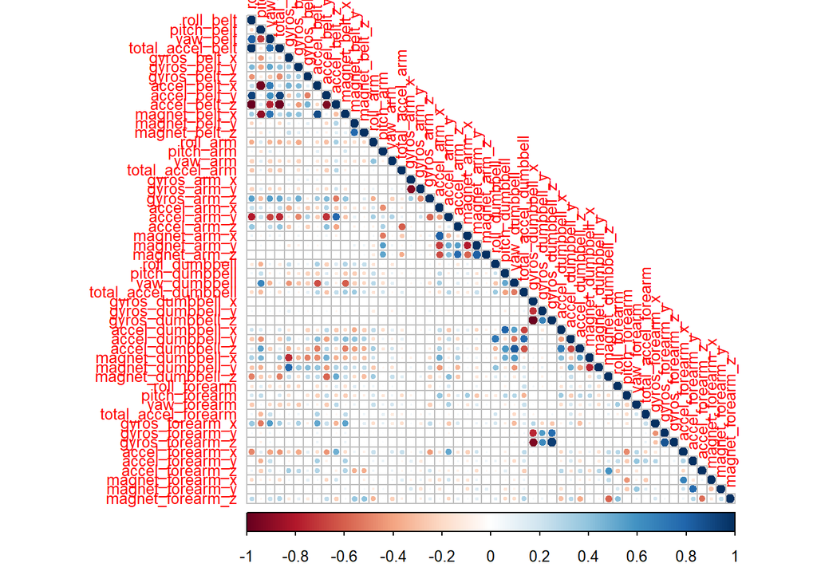

```r
# plot a correlation matrix
correlMatrix <- cor(training[, -length(training)])
#png("corrplot.png",width=480,height=480,units="px",bg="transparent")
corrplot(correlMatrix, type = "lower", tl.cex = 0.8)
```

```r
#Compute Random Forest with PCA to remove highly correlated variables
training$classe = factor(training$classe)
rf <- randomForest(Species ~ ., data=iris)
randomForestFit <- randomForest(classe~., data=training, preprocessing="pca")
print(randomForestFit)
```

```
##
## Call:
##  randomForest(formula = classe ~ ., data = training, preprocessing = "pca")
##                Type of random forest: classification
##                      Number of trees: 500
## No. of variables tried at each split: 7
##
##         OOB estimate of  error rate: 0.45%
## Confusion matrix:
##      A    B    C    D    E  class.error
## A 4182    1    1    0    1 0.0007168459
## B    9 2832    7    0    0 0.0056179775
## C    0   14 2550    3    0 0.0066225166
## D    1    0   24 2386    1 0.0107794362
## E    0    0    0    4 2702 0.0014781966
```

## Validation data

The results of the confusion matrix command are as follows:

```r
rfResVal = predict(randomForestFit,validation)
#Get an estimate of how well the model has been trained
print ("RF - Cross Validataion");
```

```
## [1] "RF - Cross Validataion"
```

```r
validation$classe = factor(validation$classe)
confusionMatrix(validation$classe, rfResVal)
```

```
## Confusion Matrix and Statistics
##
##           Reference
## Prediction    A    B    C    D    E
##          A 1017    0    0    0    0
##          B    0  727    0    0    0
##          C    0    0  652    0    0
##          D    0    0    0  610    0
##          E    0    0    0    0  664
##
## Overall Statistics
##
##                Accuracy : 1
##                  95% CI : (0.999, 1)
##     No Information Rate : 0.2771
##     P-Value [Acc > NIR] : < 2.2e-16
##
##                   Kappa : 1
##
##  Mcnemar's Test P-Value : NA
##
## Statistics by Class:
##
##                      Class: A Class: B Class: C Class: D Class: E
## Sensitivity            1.0000   1.0000   1.0000   1.0000   1.0000
## Specificity            1.0000   1.0000   1.0000   1.0000   1.0000
## Pos Pred Value         1.0000   1.0000   1.0000   1.0000   1.0000
## Neg Pred Value         1.0000   1.0000   1.0000   1.0000   1.0000
## Prevalence             0.2771   0.1981   0.1777   0.1662   0.1809
## Detection Rate         0.2771   0.1981   0.1777   0.1662   0.1809
## Detection Prevalence   0.2771   0.1981   0.1777   0.1662   0.1809
## Balanced Accuracy      1.0000   1.0000   1.0000   1.0000   1.0000
```

```r
accuracy = confusionMatrix(validation$classe, rfResVal)$overall['Accuracy']
outOfSampleError = (1 - accuracy) * 100
print("Out of sample error estimation: "); print(round(outOfSampleError, digits = 4))
```

```
## [1] "Out of sample error estimation: "
```

```
## Accuracy
##        0
```

## Testing data

Finally, the new test data is loaded and the model is applied to make predictions. The classes are returned for each of the 20 rows.

## Results

```r
# Application of the model to new data set
rfResFinal = predict(randomForestFit,testing)
print (rfResFinal)
```

```
##  1  2  3  4  5  6  7  8  9 10 11 12 13 14 15 16 17 18 19 20
##  B  A  B  A  A  E  D  B  A  A  B  C  B  A  E  E  A  B  B  B
## Levels: A B C D E
```